**SYS 6018 | Fall 2020 | University of Virginia**

### Problem 0.1: Who are you?

1. What is your name?

Congxin (David) Xu

2. Where are you from (e.g., hometown)?

Hefei, Anhui, China

3. What do you hope to do after graduation (be specific)?

Work as a Lead/Senior Data Scientist

4. List 3 interesting things about yourself.
1. I love playing board games
2. I love playing sports with a racquet, such as badminton, tennis, racquetball, squash, etc.
3. I have 3-year-old American short hair cat, Maca.

### Problem 0.2: About the course

1. What are you most excited to learn in this course?

Study different data mining techniques and understand how those techniques can be applied to the machine learning forecasting models.

2. What pre-req topics (e.g., math, coding, probability, statistics) are your weakest?

I believe math may be my weakest pre-req topic.

3. What pre-req topics are your strongest?

I think I am strong at coding, probability and statistics.

4. Would you rather see the mathematical details or coding details of a method/algorithm?

YES! Those are exactly what I am looking for in our MSDS program.

### Problem 0.3: Math Notation

1. What are the equations for the least squares coefficients in linear regression (in matrix notation)? Use $X$ for the design/predictor matrix, and $Y$ the vector of responses.

Using the matrix notation, the equation for the least squares coefficients in linear regression is
$$Y = X \pmb{\beta} + \pmb{\varepsilon}$$
where
$$Y = \begin{bmatrix} y_1 \\ y_2 \\ \vdots \\ y_n
\end{bmatrix}, \enspace
X = \begin{bmatrix} 1 & x_{11} & x_{12} & \ldots & x_{1k} \\
1 & x_{21} & x_{22} & \ldots & x_{2k} \\
\vdots & \vdots & \vdots & & \vdots \\
1 & x_{n1} & x_{n2} & \ldots & x_{nk} \\
\end{bmatrix} , \enspace
\pmb{\beta} = \begin{bmatrix} \beta_0 \\ \beta_1 \\ \vdots \\ \beta_k
\end{bmatrix}, \enspace
\pmb{\varepsilon} = \begin{bmatrix} \varepsilon_1 \\ \varepsilon_2 \\ \vdots \\ \varepsilon_n \end{bmatrix}$$

2. Let $x_1, x_2, \ldots, x_n$ be a sample of length of time that a customer is on the phone with a call center help line. We feel comfortable modeling the data as coming from an *exponential distribution*. What is the MLE (Maximum Likelihood Estimate) of the parameter? Show your steps.

The probability density function of the exponential distribution is defined as

$$f(x;\lambda) = \begin{cases}
\lambda e^{-\lambda x} & \text{if } x \geq 0 \\
0 & \text{if } x<0
\end{cases}$$

Its likelihood function is

$$\mathcal{L}(\lambda, x_1, \dots, x_n) = \prod_{i = 1}^n f(x_i, \lambda) = \prod_{i = 1}^n \lambda e^{-\lambda x} = \lambda^n e^{-\lambda\sum_{i=1}^n x_i}$$

To calculate the maximum likelihood estimator I solved the equation

$$\frac{d\ln\left(\mathcal{L}(\lambda,x_1,\dots,x_n)\right)}{d\lambda}\overset{!}{=}0$$

for $\lambda$.

$$\begin{align}
\frac{d\ln\left(\mathcal{L}(\lambda,x_1,\dots,x_n)\right)}{d\lambda}
&= \frac{d\ln\left(\lambda^ne^{-\lambda\sum_{i=1}^nx_i}\right)}{d\lambda} \\
&= \frac{d\ln\left(n\ln(\lambda)-\lambda\sum_{i=1}^n x_i\right)}{d\lambda} \\
&= \frac{n}{\lambda}-\sum_{i=1}^n x_i
\end{align}$$

Finally we get
$$\lambda = \frac{n}{\sum\limits_{i=1}^n x_i}$$

*Resource*: https://math.stackexchange.com/questions/101481/calculating-maximum-likelihood-estimation-of-the-exponential-distribution-and-pr

### Problem 0.4: Coding

1. Simulate 100 observations from the following model:
- $X \sim N(1, 1)$
- $Y \sim N(1 + 2X, 2)$
- $Z = \begin{cases} 1 &\quad Y<0 \\ 2 &\quad Y \ge 0 \end{cases}$

```r
set.seed(666)
x <- rnorm(n = 100, mean = 1, sd = 1)
y <- rnorm(n = 100, mean = 1 + 2*x, sd = 2)
z <- ifelse(y < 0, 1, 2)
```

2. Make a scatter plot of the data. Put $X$ on the x-axis and $Y$ on the y-axis. Color the points according to $Z$.

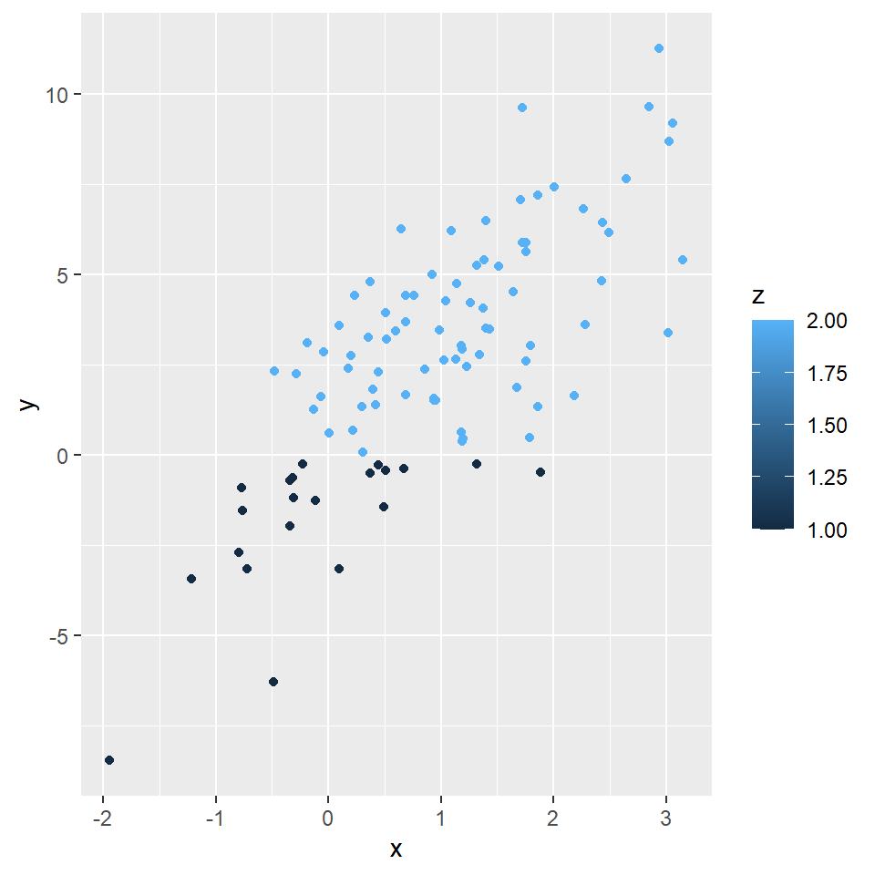

```r
library(ggplot2)
df <- data.frame(x, y, z)
ggplot(data = df) + geom_point(aes(x = x, y = y, color = z))
```